# AS_PROJECT

```python
import numpy as np
import pandas as pd
import scipy.stats as stats
```

```python
# joint probability of the people who planned to purchase to actually place an order
p=400               # people who actually place an order
q=2000              # people who planned to purchase product A
joint_pq=400/2000
print('Joint probability of the people who planned to purchase and actually placed an order. is %1.3f'  % joint_pq)
```

```
Joint probability of the people who planned to purchase and actually placed an order. is 0.200
```

```python
# joint probability of the people who planned to purchase and actually placed an order, given that people planned to purchase
r= 500          #people planned to purchase
joint_pqr=(p/q)/(r/q)
print('the joint probability of the people who planned to purchase and actually placed an order  given that people planned to purchase :', joint_pqr)
```

```
the joint probability of the people who planned to purchase and actually placed an order  given that people planned to purchase : 0.8
```

# 2. An electrical manufacturing company conducts quality checks at specified periods on the products it manufactures. Historically, the failure rate for the manufactured item is 5%. Suppose a random sample of 10 manufactured items is selected. Answer the following questions.

## Part 1 Q 2 A Probability that none of the items are defective?

```python
import matplotlib.pyplot as plt
from scipy.stats import binom
```

```python
p   =  0.05 # failure rate for LED light bulbs that the company manufactures is 5%
n   =  10 # sample size
k   =  np.arange(0,11) # An array of quantiles
```

```python
binom=stats.binom.pmf(k,n,p)
print(binom)
```

```
[5.98736939e-01 3.15124705e-01 7.46347985e-02 1.04750594e-02
 9.64808106e-04 6.09352488e-05 2.67259863e-06 8.03789062e-08
 1.58642578e-09 1.85546875e-11 9.76562500e-14]
```

```python
print('None of the items are defective is %1.3f' %binom[0])
```

```
None of the items are defective is 0.599
```

## Part 1 Q 2 B Probability that exactly one of the items is defective?

```python
print('Probability that exactly one of the items is defective %1.3f' %binom[1])
```

```
Probability that exactly one of the items is defective 0.315
```

## Part 1 Q 2 C Probability that two or fewer of the items are defective?

```python
cumbinom=stats.binom.cdf(k,n,p)
print(cumbinom)
```

```
[0.59873694 0.91386164 0.98849644 0.9989715  0.99993631 0.99999725
 0.99999992 1.         1.         1.         1.        ]
```

```python
print('Probability that two or fewer of the items are defective %1.3f' %cumbinom[2])
```

```
Probability that two or fewer of the items are defective 0.988
```

## Part 1 Q 2 D Probability that three or more of the items are defective ?

```python
Prob=1-cumbinom[2]
print('Probability that three or more of the items are defective %1.3f' %Prob)
```

```
Probability that three or more of the items are defective 0.012
```

# 3. A car salesman sells on an average 3 cars per week.

## Part 1 Q 3 A What is Probability that in a given week he will sell some cars?

```python
rate=3
n=np.arange(0,20)
cumpoisson=stats.poisson.cdf(n,rate)
print(cumpoisson)
```

```
[0.04978707 0.19914827 0.42319008 0.64723189 0.81526324 0.91608206
 0.96649146 0.9880955  0.99619701 0.99889751 0.99970766 0.99992861
 0.99998385 0.9999966  0.99999933 0.99999988 0.99999998 1.
 1.         1.        ]
```

```python
P=1-cumpoisson[0]
print('Probability that in a given week he will sell some cars %1.4f' %P)
```

```
Probability that in a given week he will sell some cars 0.9502
```

## Part 1 Q 3 B What is Probability that in a given week he will sell 2 or more but less than 5 cars?

```python
X=cumpoisson[4]-cumpoisson[1]
print('Probability that in a given week he will sell 2 or more but less than 5 cars %1.4f' %X)
```

```
Probability that in a given week he will sell 2 or more but less than 5 cars 0.6161
```

## Part 1 Q 3 C Plot the poisson distribution function for cumulative probability of cars sold per-week vs number of cars sold per week

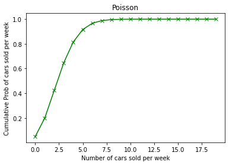

```python
poisson = stats.poisson.cdf(n,rate)
plt.plot(n,poisson, 'x-',color='g')
plt.title('Poisson')
plt.xlabel('Number of cars sold per week')
plt.ylabel('Cumulative Prob of cars sold per week');
```

# 4. Accuracy in understanding orders for a speech based bot at a restaurant is important for the Company X which has designed, marketed and launched the product for a contactless delivery due to the COVID-19 pandemic. Recognition accuracy that measures the percentage of orders that are taken correctly is 86.8%. Suppose that you place an order with the bot and two friends of yours independently place orders with the same bot. Answer the following questions.

## Part 1 Q 4 A What is the probability that all three orders will be recognised correctly?

```python
p=0.868
n=3
k=np.arange(4)
binom_1=stats.binom.pmf(k,n,p)
print(binom_1)
```

```
[0.00229997 0.0453721  0.2983559  0.65397203]
```

```python
print('the probability that all three orders will be recognised correctly %0.3f' %binom_1[3])
```

```
the probability that all three orders will be recognised correctly 0.654
```

## Part 1 Q 4 B What is the probability that none of the three orders will be recognised correctly?

```python
print('the probability that none of the three orders will be recognised correctly %0.3f' %binom_1[0])
```

```
the probability that none of the three orders will be recognised correctly 0.002
```

## Part 1 Q 4 C What is the probability that at least two of the three orders will be recognised correctly?

```python
cumbinom_1=stats.binom.cdf(k,n,p)
print(cumbinom_1)
```

```
[0.00229997 0.04767206 0.34602797 1.        ]
```

```python
# at least two orders means p(x>=2) means 1-p(x=1)
Y=1-cumbinom_1[1]
print('What is the probability that at least two of the three orders will be recognised correctly %0.3f' %Y)
```

```
What is the probability that at least two of the three orders will be recognised correctly 0.952
```

# Part 1 Q 5 Explain 1 real life industry scenario (other than the ones mentioned above) where you can use theconcepts learnt in this module of Applied Statistics to get data driven business solution.

## In my ABC company we are using Methanol solvent on average 5 liters per week

## 1) what is the probablity of using Methanol less than 3 liters per week

```python
rate=5
n=np.arange(0,15)
cumpoisson_1=stats.poisson.cdf(n,rate)
print(cumpoisson_1)
```

```
[0.00673795 0.04042768 0.12465202 0.26502592 0.44049329 0.61596065
 0.76218346 0.86662833 0.93190637 0.96817194 0.98630473 0.99454691
 0.99798115 0.99930201 0.99977375]
```

```python
print('the probablity of using Methanol less than 3 liters per week %0.3f'%cumpoisson_1[2])
```

```
the probablity of using Methanol less than 3 liters per week 0.125
```

```python
K=1-cumpoisson_1[3]
print('the probablity of using Methanol more than 4 liters per week  %0.3f'%K)
```

```
the probablity of using Methanol more than 4 liters per week  0.735
```

# PART-B

• DOMAIN: Sports

• CONTEXT: Company X manages the men's top professional basketball division of the American league system. The dataset contains information on all the teams that have participated in all the past tournaments. It has data about how many baskets each team scored, conceded, how many times they came within the first 2 positions, how many tournaments they have qualified, their best position in the past, etc.

• DATA DESCRIPTION: Basketball.csv - The data set contains information on all the teams so far participated in all the past tournaments.

• DATA DICTIONARY:

1. Team: Team’s name
2. Tournament: Number of played tournaments.
3. Score: Team’s score so far.
4. PlayedGames: Games played by the team so far.
5. WonGames: Games won by the team so far.
6. DrawnGames: Games drawn by the team so far.
7. LostGames: Games lost by the team so far.
8. BasketScored: Basket scored by the team so far.
9. BasketGiven: Basket scored against the team so far.
10. TournamentChampion: How many times the team was a champion of the tournaments so far.
11. Runner-up: How many times the team was a runners-up of the tournaments so far.
12. TeamLaunch: Year the team was launched on professional basketball.
13. HighestPositionHeld: Highest position held by the team amongst all the tournaments played.

• PROJECT OBJECTIVE: Company’s management wants to invest on proposals on managing some of the best teams in the league. The analytics department has been assigned with a task of creating a report on the performance shown by the teams. Some of the older teams are already in contract with competitors. Hence Company X wants to understand which teams they can approach which will be a deal win for them.

## Part 2 Q1 Read the data set, clean the data and prepare final dataset to be used for analysis.

```python
df=pd.read_csv('Basketball.csv')
df.head()
```

|  | Team | Tournament | Score | PlayedGames | WonGames | DrawnGames | LostGames | BasketScored | BasketGiven | TournamentChampion | Runner-up | TeamLaunch | HighestPositionHeld |
| --- | --- | --- | --- | --- | --- | --- | --- | --- | --- | --- | --- | --- | --- |
| 0 | Team 1 | 86 | 4385 | 2762 | 1647 | 552 | 563 | 5947 | 3140 | 33 | 23 | 1929 | 1 |
| 1 | Team 2 | 86 | 4262 | 2762 | 1581 | 573 | 608 | 5900 | 3114 | 25 | 25 | 1929 | 1 |
| 2 | Team 3 | 80 | 3442 | 2614 | 1241 | 598 | 775 | 4534 | 3309 | 10 | 8 | 1929 | 1 |
| 3 | Team 4 | 82 | 3386 | 2664 | 1187 | 616 | 861 | 4398 | 3469 | 6 | 6 | 1931to32 | 1 |
| 4 | Team 5 | 86 | 3368 | 2762 | 1209 | 633 | 920 | 4631 | 3700 | 8 | 7 | 1929 | 1 |

```python
print(df.shape)
```

```
(61, 13)
```

```python
df.tail()
```

|  | Team | Tournament | Score | PlayedGames | WonGames | DrawnGames | LostGames | BasketScored | BasketGiven | TournamentChampion | Runner-up | TeamLaunch | HighestPositionHeld |
| --- | --- | --- | --- | --- | --- | --- | --- | --- | --- | --- | --- | --- | --- |
| 56 | Team 57 | 1 | 34 | 38 | 8 | 10 | 20 | 38 | 66 | - | - | 2009-10 | 20 |
| 57 | Team 58 | 1 | 22 | 30 | 7 | 8 | 15 | 37 | 57 | - | - | 1956-57 | 16 |
| 58 | Team 59 | 1 | 19 | 30 | 7 | 5 | 18 | 51 | 85 | - | - | 1951~52 | 16 |
| 59 | Team 60 | 1 | 14 | 30 | 5 | 4 | 21 | 34 | 65 | - | - | 1955-56 | 15 |
| 60 | Team 61 | 1 | - | - | - | - | - | - | - | - | - | 2017~18 | 9 |

the row number 60 that is Team 61 has no values existed or incorrect data.so we drop the entire row

```python
df.drop(60,inplace=True)
df.tail()
```

|  | Team | Tournament | Score | PlayedGames | WonGames | DrawnGames | LostGames | BasketScored | BasketGiven | TournamentChampion | Runner-up | TeamLaunch | HighestPositionHeld |
| --- | --- | --- | --- | --- | --- | --- | --- | --- | --- | --- | --- | --- | --- |
| 55 | Team 56 | 1 | 35 | 38 | 8 | 11 | 19 | 36 | 55 | - | - | 2016_17 | 17 |
| 56 | Team 57 | 1 | 34 | 38 | 8 | 10 | 20 | 38 | 66 | - | - | 2009-10 | 20 |
| 57 | Team 58 | 1 | 22 | 30 | 7 | 8 | 15 | 37 | 57 | - | - | 1956-57 | 16 |
| 58 | Team 59 | 1 | 19 | 30 | 7 | 5 | 18 | 51 | 85 | - | - | 1951~52 | 16 |
| 59 | Team 60 | 1 | 14 | 30 | 5 | 4 | 21 | 34 | 65 | - | - | 1955-56 | 15 |

```python
print(df.info())
```

```
<class 'pandas.core.frame.DataFrame'>
RangeIndex: 60 entries, 0 to 59
Data columns (total 13 columns):
 #   Column               Non-Null Count  Dtype
---  ------               --------------  -----
 0   Team                 60 non-null     object
 1   Tournament           60 non-null     int64
 2   Score                60 non-null     object
 3   PlayedGames          60 non-null     object
 4   WonGames             60 non-null     object
 5   DrawnGames           60 non-null     object
 6   LostGames            60 non-null     object
 7   BasketScored         60 non-null     object
 8   BasketGiven          60 non-null     object
 9   TournamentChampion   60 non-null     object
 10  Runner-up            60 non-null     object
 11  TeamLaunch           60 non-null     object
 12  HighestPositionHeld  60 non-null     int64
dtypes: int64(2), object(11)
memory usage: 6.2+ KB
None
```

```python
df.isnull().sum()
```

```
Team                   0
Tournament             0
Score                  0
PlayedGames            0
WonGames               0
DrawnGames             0
LostGames              0
BasketScored           0
BasketGiven            0
TournamentChampion     0
Runner-up              0
TeamLaunch             0
HighestPositionHeld    0
dtype: int64
```

```python
df.sample(10)
```

|  | Team | Tournament | Score | PlayedGames | WonGames | DrawnGames | LostGames | BasketScored | BasketGiven | TournamentChampion | Runner-up | TeamLaunch | HighestPositionHeld |
| --- | --- | --- | --- | --- | --- | --- | --- | --- | --- | --- | --- | --- | --- |
| 28 | Team 29 | 12 | 421 | 380 | 125 | 81 | 174 | 458 | 623 | - | - | 1930-31 | 6 |
| 56 | Team 57 | 1 | 34 | 38 | 8 | 10 | 20 | 38 | 66 | - | - | 2009-10 | 20 |
| 7 | Team 8 | 70 | 2573 | 2302 | 864 | 577 | 861 | 3228 | 3230 | 2 | 3 | 1929 | 1 |
| 34 | Team 35 | 11 | 285 | 334 | 103 | 79 | 152 | 419 | 588 | - | - | 1941-42 | 4 |
| 38 | Team 39 | 4 | 190 | 160 | 52 | 45 | 63 | 199 | 241 | - | - | 1994-95 | 10 |
| 11 | Team 12 | 51 | 1789 | 1698 | 586 | 389 | 723 | 2278 | 2624 | - | - | 1939-40 | 4 |
| 37 | Team 38 | 9 | 230 | 282 | 82 | 63 | 137 | 285 | 430 | - | - | 1962-63 | 5 |
| 3 | Team 4 | 82 | 3386 | 2664 | 1187 | 616 | 861 | 4398 | 3469 | 6 | 6 | 1931to32 | 1 |
| 24 | Team 25 | 12 | 553 | 456 | 147 | 112 | 197 | 520 | 633 | - | - | 2004to05 | 6 |
| 57 | Team 58 | 1 | 22 | 30 | 7 | 8 | 15 | 37 | 57 | - | - | 1956-57 | 16 |

By the obsevation above , there is no null values existed but by taking a sample and checking tail in dataframe we observed some Hyphene('-') symbol.we may convert it into as Nan value

- But the obsevaton of column Highestpositionheld , The postion have 1 and 2 has the values of TournmentChampion and Runner-up
- so we replcing the Hyphene values with zero for caluculation and purpose

```python
df[['TournamentChampion','Runner-up']]=df[['TournamentChampion','Runner-up']].replace('-',0)
df.sample(3)
```

|  | Team | Tournament | Score | PlayedGames | WonGames | DrawnGames | LostGames | BasketScored | BasketGiven | TournamentChampion | Runner-up | TeamLaunch | HighestPositionHeld |
| --- | --- | --- | --- | --- | --- | --- | --- | --- | --- | --- | --- | --- | --- |
| 44 | Team 45 | 7 | 107 | 130 | 43 | 21 | 66 | 227 | 308 | 0 | 0 | 1929 | 3 |
| 55 | Team 56 | 1 | 35 | 38 | 8 | 11 | 19 | 36 | 55 | 0 | 0 | 2016_17 | 17 |
| 56 | Team 57 | 1 | 34 | 38 | 8 | 10 | 20 | 38 | 66 | 0 | 0 | 2009-10 | 20 |

```python
print(df.dtypes)
```

```
Team                   object
Tournament              int64
Score                  object
PlayedGames            object
WonGames               object
DrawnGames             object
LostGames              object
BasketScored           object
BasketGiven            object
TournamentChampion     object
Runner-up              object
TeamLaunch             object
HighestPositionHeld     int64
dtype: object
```

As we observe there are so many object datatypes,But we see so many columns are numerical in nature we need to convert datatype to numerical

```python
df.iloc[:,1:11]=df.iloc[:,1:11].astype('int')
df.info()
```

```
<class 'pandas.core.frame.DataFrame'>
RangeIndex: 60 entries, 0 to 59
Data columns (total 13 columns):
 #   Column               Non-Null Count  Dtype
---  ------               --------------  -----
 0   Team                 60 non-null     object
 1   Tournament           60 non-null     int32
 2   Score                60 non-null     int32
 3   PlayedGames          60 non-null     int32
 4   WonGames             60 non-null     int32
 5   DrawnGames           60 non-null     int32
 6   LostGames            60 non-null     int32
 7   BasketScored         60 non-null     int32
 8   BasketGiven          60 non-null     int32
 9   TournamentChampion   60 non-null     int32
 10  Runner-up            60 non-null     int32
 11  TeamLaunch           60 non-null     object
 12  HighestPositionHeld  60 non-null     int64
dtypes: int32(10), int64(1), object(2)
memory usage: 3.9+ KB
```

```python
x=['~','_','to']
for i in x:
    df['TeamLaunch'] = df['TeamLaunch'].str.replace(i, '-')
```

```python
df.sample(3)
```

|  | Team | Tournament | Score | PlayedGames | WonGames | DrawnGames | LostGames | BasketScored | BasketGiven | TournamentChampion | Runner-up | TeamLaunch | HighestPositionHeld |
| --- | --- | --- | --- | --- | --- | --- | --- | --- | --- | --- | --- | --- | --- |
| 8 | Team 9 | 58 | 2109 | 1986 | 698 | 522 | 766 | 2683 | 2847 | 0 | 1 | 1939-40 | 2 |
| 56 | Team 57 | 1 | 34 | 38 | 8 | 10 | 20 | 38 | 66 | 0 | 0 | 2009-10 | 20 |
| 18 | Team 19 | 27 | 1148 | 988 | 333 | 256 | 399 | 1182 | 1371 | 0 | 0 | 1960-61 | 3 |

```python
df.describe().T
```

|  | count | mean | std | min | 25% | 50% | 75% | max |
| --- | --- | --- | --- | --- | --- | --- | --- | --- |
| Tournament | 60.0 | 24.383333 | 26.884620 | 1.0 | 4.00 | 12.0 | 39.00 | 86.0 |
| Score | 60.0 | 916.450000 | 1138.342899 | 14.0 | 104.25 | 395.5 | 1360.50 | 4385.0 |
| PlayedGames | 60.0 | 810.100000 | 877.465393 | 30.0 | 115.50 | 424.5 | 1345.50 | 2762.0 |
| WonGames | 60.0 | 309.033333 | 408.481395 | 5.0 | 34.75 | 124.0 | 432.75 | 1647.0 |
| DrawnGames | 60.0 | 192.083333 | 201.985508 | 4.0 | 26.25 | 98.5 | 331.50 | 633.0 |
| LostGames | 60.0 | 308.816667 | 294.508639 | 15.0 | 62.75 | 197.5 | 563.50 | 1070.0 |
| BasketScored | 60.0 | 1159.350000 | 1512.063948 | 34.0 | 154.50 | 444.0 | 1669.75 | 5947.0 |
| BasketGiven | 60.0 | 1159.233333 | 1163.946914 | 55.0 | 236.00 | 632.5 | 2001.25 | 3889.0 |
| TournamentChampion | 60.0 | 1.450000 | 5.515540 | 0.0 | 0.00 | 0.0 | 0.00 | 33.0 |
| Runner-up | 60.0 | 1.433333 | 4.574679 | 0.0 | 0.00 | 0.0 | 0.00 | 25.0 |
| HighestPositionHeld | 60.0 | 7.050000 | 5.315232 | 1.0 | 3.00 | 6.0 | 10.00 | 20.0 |

By observing above data ,by comparing mean and median values it seemed to be right skewed. we may see visually as follows

## Part 2 Q2 Perform detailed statistical analysis and EDA using univariate, bi-variate and multivariate EDA techniques to get data driven insights on recommending which teams they can approach which will be a deal win for them. Also as a data and statistics expert you have to develop a detailed performance report using this data.

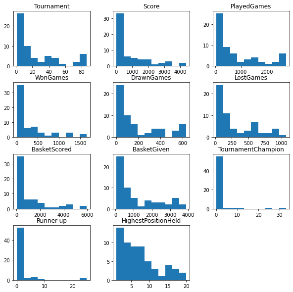

```python
df.hist(figsize=(10,10),grid=False);
```

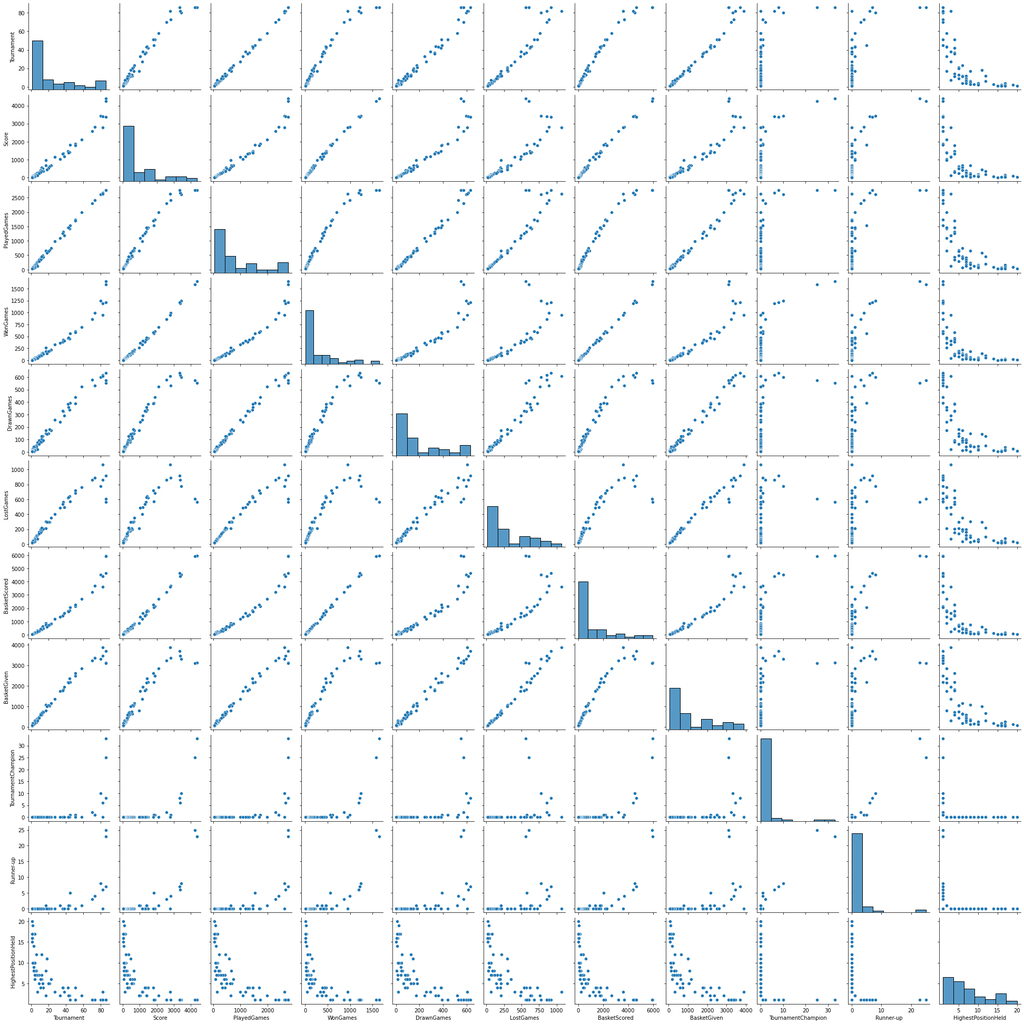

```python
import seaborn as sns
sns.pairplot(df);
```

```python
df_corr=df.corr()
df_corr
```

|  | Tournament | Score | PlayedGames | WonGames | DrawnGames | LostGames | BasketScored | BasketGiven | TournamentChampion | Runner-up | HighestPositionHeld |
| --- | --- | --- | --- | --- | --- | --- | --- | --- | --- | --- | --- |
| Tournament | 1.000000 | 0.981258 | 0.998683 | 0.971749 | 0.989295 | 0.949350 | 0.974867 | 0.987781 | 0.589304 | 0.645924 | -0.708002 |
| Score | 0.981258 | 1.000000 | 0.979687 | 0.997232 | 0.958090 | 0.878780 | 0.996634 | 0.943801 | 0.715014 | 0.764819 | -0.669215 |
| PlayedGames | 0.998683 | 0.979687 | 1.000000 | 0.967486 | 0.993972 | 0.955925 | 0.969970 | 0.990020 | 0.575072 | 0.633101 | -0.711065 |
| WonGames | 0.971749 | 0.997232 | 0.967486 | 1.000000 | 0.939416 | 0.851436 | 0.999312 | 0.925745 | 0.752904 | 0.797849 | -0.647819 |
| DrawnGames | 0.989295 | 0.958090 | 0.993972 | 0.939416 | 1.000000 | 0.972786 | 0.942234 | 0.992479 | 0.503378 | 0.566021 | -0.720248 |
| LostGames | 0.949350 | 0.878780 | 0.955925 | 0.851436 | 0.972786 | 1.000000 | 0.857843 | 0.985041 | 0.324025 | 0.391645 | -0.726172 |
| BasketScored | 0.974867 | 0.996634 | 0.969970 | 0.999312 | 0.942234 | 0.857843 | 1.000000 | 0.931079 | 0.743847 | 0.791041 | -0.648672 |
| BasketGiven | 0.987781 | 0.943801 | 0.990020 | 0.925745 | 0.992479 | 0.985041 | 0.931079 | 1.000000 | 0.471618 | 0.533448 | -0.727323 |
| TournamentChampion | 0.589304 | 0.715014 | 0.575072 | 0.752904 | 0.503378 | 0.324025 | 0.743847 | 0.471618 | 1.000000 | 0.971533 | -0.304307 |
| Runner-up | 0.645924 | 0.764819 | 0.633101 | 0.797849 | 0.566021 | 0.391645 | 0.791041 | 0.533448 | 0.971533 | 1.000000 | -0.359191 |
| HighestPositionHeld | -0.708002 | -0.669215 | -0.711065 | -0.647819 | -0.720248 | -0.726172 | -0.648672 | -0.727323 | -0.304307 | -0.359191 | 1.000000 |

By observing the correlation data , The columns are highly correlated with other columns

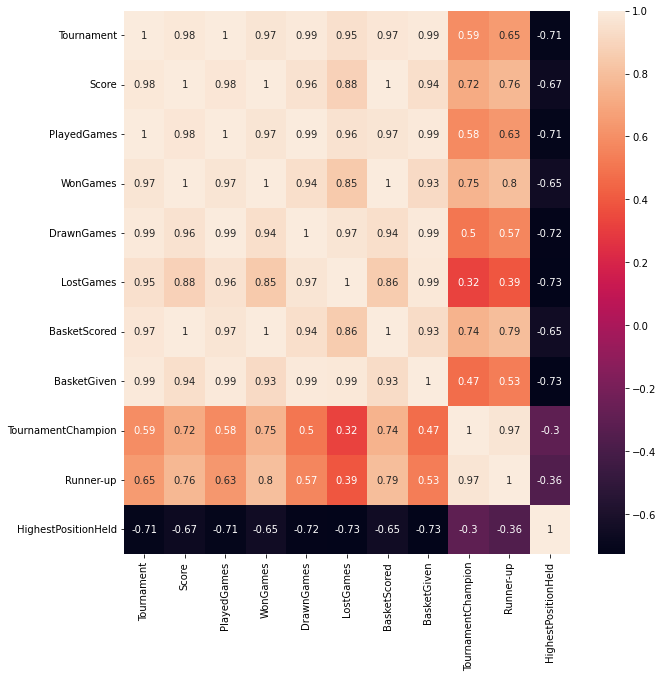

```python
plt.figure(figsize=(10,10))
sns.heatmap(df_corr,annot=True);
```

Here we are creating some new columns

```python
df['High_perf_team']=round(df['WonGames']/df['PlayedGames'],3)
df.head(3)
```

|  | Team | Tournament | Score | PlayedGames | WonGames | DrawnGames | LostGames | BasketScored | BasketGiven | TournamentChampion | Runner-up | TeamLaunch | HighestPositionHeld | High_perf_team |
| --- | --- | --- | --- | --- | --- | --- | --- | --- | --- | --- | --- | --- | --- | --- |
| 0 | Team 1 | 86 | 4385 | 2762 | 1647 | 552 | 563 | 5947 | 3140 | 33 | 23 | 1929 | 1 | 0.596 |
| 1 | Team 2 | 86 | 4262 | 2762 | 1581 | 573 | 608 | 5900 | 3114 | 25 | 25 | 1929 | 1 | 0.572 |
| 2 | Team 3 | 80 | 3442 | 2614 | 1241 | 598 | 775 | 4534 | 3309 | 10 | 8 | 1929 | 1 | 0.475 |

```python
hpt=df[['Team','High_perf_team']].sort_values(by='High_perf_team',ascending=False)
hpt.head()
```

|  | Team | High_perf_team |
| --- | --- | --- |
| 0 | Team 1 | 0.596 |
| 1 | Team 2 | 0.572 |
| 2 | Team 3 | 0.475 |
| 3 | Team 4 | 0.446 |
| 4 | Team 5 | 0.438 |

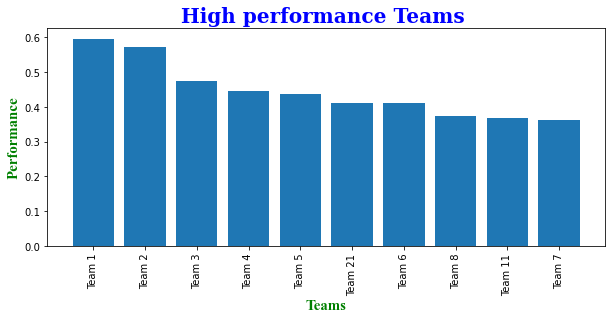

```python
plt.figure(figsize=(10,4))
font1 = {'family':'Times New Roman','color':'green','size':15,'weight':'semibold'}
font2 = {'family':'serif','color':'blue','size':20,'weight':'bold'}
plt.bar(hpt['Team'].head(10),hpt['High_perf_team'].head(10))
plt.xticks(rotation=90)
plt.xlabel('Teams',fontdict=font1)
plt.ylabel('Performance',fontdict=font1)
plt.title('High performance Teams ',fontdict=font2);
```

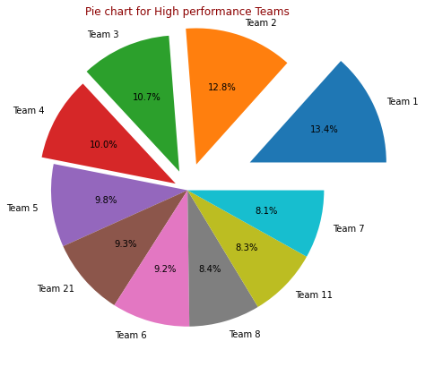

```python
plt.figure(figsize=(15,7))
plt.pie(hpt['High_perf_team'].head(10),labels=hpt['Team'].head(10),autopct='%1.1f%%',explode = (0.50,0.20,0.15,0.10,0,0,0,0,0,0));
plt.title('Pie chart for High performance Teams',c='darkred');
```

```python
print('High performance teams :\n',hpt.Team.head())
```

```
High performance teams :
 0    Team 1
1    Team 2
2    Team 3
3    Team 4
4    Team 5
Name: Team, dtype: object
```

```python
df['Low_perf_team']=round(df['LostGames']/df['PlayedGames'],3)
df.head()
```

|  | Team | Tournament | Score | PlayedGames | WonGames | DrawnGames | LostGames | BasketScored | BasketGiven | TournamentChampion | Runner-up | TeamLaunch | HighestPositionHeld | High_perf_team | Low_perf_team |
| --- | --- | --- | --- | --- | --- | --- | --- | --- | --- | --- | --- | --- | --- | --- | --- |
| 0 | Team 1 | 86 | 4385 | 2762 | 1647 | 552 | 563 | 5947 | 3140 | 33 | 23 | 1929 | 1 | 0.596 | 0.204 |
| 1 | Team 2 | 86 | 4262 | 2762 | 1581 | 573 | 608 | 5900 | 3114 | 25 | 25 | 1929 | 1 | 0.572 | 0.220 |
| 2 | Team 3 | 80 | 3442 | 2614 | 1241 | 598 | 775 | 4534 | 3309 | 10 | 8 | 1929 | 1 | 0.475 | 0.296 |
| 3 | Team 4 | 82 | 3386 | 2664 | 1187 | 616 | 861 | 4398 | 3469 | 6 | 6 | 1931-32 | 1 | 0.446 | 0.323 |
| 4 | Team 5 | 86 | 3368 | 2762 | 1209 | 633 | 920 | 4631 | 3700 | 8 | 7 | 1929 | 1 | 0.438 | 0.333 |

```python
lpt=df[['Team','Low_perf_team']].sort_values('Low_perf_team',ascending=False)
lpt.head()
```

|  | Team | Low_perf_team |
| --- | --- | --- |
| 59 | Team 60 | 0.700 |
| 54 | Team 55 | 0.603 |
| 58 | Team 59 | 0.600 |
| 49 | Team 50 | 0.574 |
| 46 | Team 47 | 0.569 |

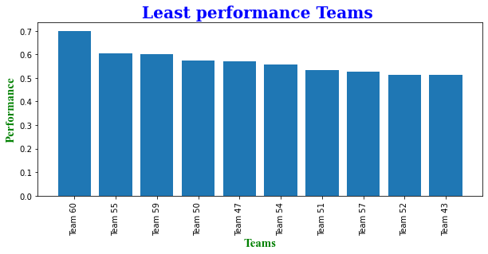

```python
plt.figure(figsize=(10,4))
font1 = {'family':'Times New Roman','color':'green','size':15,'weight':'semibold'}
font2 = {'family':'serif','color':'blue','size':20,'weight':'bold'}
plt.bar(lpt['Team'].head(10),lpt['Low_perf_team'].head(10))
plt.xticks(rotation=90)
plt.xlabel('Teams',fontdict=font1)
plt.ylabel('Performance',fontdict=font1)
plt.title('Least performance Teams ',fontdict=font2);
```

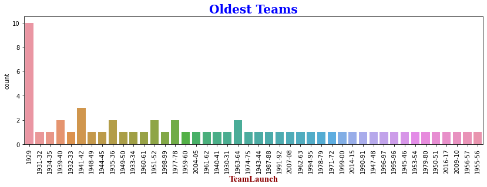

```python
plt.figure(figsize=(14,4))
sns.countplot(data=df,x='TeamLaunch')
font1 = {'family':'Times New Roman','color':'darkred','size':15,'weight':'semibold'}
font2 = {'family':'serif','color':'blue','size':20,'weight':'bold'}
plt.xlabel('TeamLaunch',fontdict=font1)
plt.xticks(rotation=90)
plt.title('Oldest Teams',fontdict=font2);
```

```python
print(df[df['TeamLaunch']=='1929'].TeamLaunch.value_counts())
```

```
1929    10
Name: TeamLaunch, dtype: int64
```

```python
old_team=df[['Team','TeamLaunch']].loc[df['TeamLaunch']=='1929']
print(old_team)
```

```
       Team TeamLaunch
0    Team 1       1929
1    Team 2       1929
2    Team 3       1929
4    Team 5       1929
6    Team 7       1929
7    Team 8       1929
13  Team 14       1929
44  Team 45       1929
51  Team 52       1929
53  Team 54       1929
```

```python
print('oldest teams : \n ',old_team.Team.head())
```

```
oldest teams :
  0    Team 1
1    Team 2
2    Team 3
4    Team 5
6    Team 7
Name: Team, dtype: object
```

```python
df['tourn_win_per']=round(df.TournamentChampion/df.Tournament,3)
df.head(3)
```

|  | Team | Tournament | Score | PlayedGames | WonGames | DrawnGames | LostGames | BasketScored | BasketGiven | TournamentChampion | Runner-up | TeamLaunch | HighestPositionHeld | High_perf_team | Low_perf_team | tourn_win_per |
| --- | --- | --- | --- | --- | --- | --- | --- | --- | --- | --- | --- | --- | --- | --- | --- | --- |
| 0 | Team 1 | 86 | 4385 | 2762 | 1647 | 552 | 563 | 5947 | 3140 | 33 | 23 | 1929 | 1 | 0.596 | 0.204 | 0.384 |
| 1 | Team 2 | 86 | 4262 | 2762 | 1581 | 573 | 608 | 5900 | 3114 | 25 | 25 | 1929 | 1 | 0.572 | 0.220 | 0.291 |
| 2 | Team 3 | 80 | 3442 | 2614 | 1241 | 598 | 775 | 4534 | 3309 | 10 | 8 | 1929 | 1 | 0.475 | 0.296 | 0.125 |

```python
twp=df[['Team','tourn_win_per']].sort_values('tourn_win_per',ascending=False)
twp.head()
```

|  | Team | tourn_win_per |
| --- | --- | --- |
| 0 | Team 1 | 0.384 |
| 1 | Team 2 | 0.291 |
| 2 | Team 3 | 0.125 |
| 4 | Team 5 | 0.093 |
| 3 | Team 4 | 0.073 |

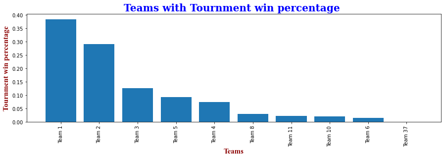

```python
plt.figure(figsize=(15,4))
plt.bar(twp['Team'].head(10),twp['tourn_win_per'].head(10))
plt.xticks(rotation=90)
plt.xlabel('Teams',fontdict=font1)
plt.ylabel('Tournment win percentage',fontdict=font1)
plt.title('Teams with Tournment win percentage ',fontdict=font2);
```

[figure not shown]

```python
plt.figure(figsize=(15,7))
plt.pie(twp['tourn_win_per'].head(10),labels=hpt['Team'].head(10),autopct='%1.1f%%',explode = (0.20,0.10,0.05,0.03,0,0,0,0,0,0));
plt.title('Tournment winner Teams',c='darkred');
```

```python
print('most of the Tournament winning Teams : \n' , twp.Team.head())
```

```
most of the Tournament winning Teams :
 0    Team 1
1    Team 2
2    Team 3
4    Team 5
3    Team 4
Name: Team, dtype: object
```

```python
df['Runner_up_per']=round(df['Runner-up']/df.Tournament,3)
df.head()
```

|  | Team | Tournament | Score | PlayedGames | WonGames | DrawnGames | LostGames | BasketScored | BasketGiven | TournamentChampion | Runner-up | TeamLaunch | HighestPositionHeld | High_perf_team | Low_perf_team | tourn_win_per | Runner_up_per |
| --- | --- | --- | --- | --- | --- | --- | --- | --- | --- | --- | --- | --- | --- | --- | --- | --- | --- |
| 0 | Team 1 | 86 | 4385 | 2762 | 1647 | 552 | 563 | 5947 | 3140 | 33 | 23 | 1929 | 1 | 0.596 | 0.204 | 0.384 | 0.267 |
| 1 | Team 2 | 86 | 4262 | 2762 | 1581 | 573 | 608 | 5900 | 3114 | 25 | 25 | 1929 | 1 | 0.572 | 0.220 | 0.291 | 0.291 |
| 2 | Team 3 | 80 | 3442 | 2614 | 1241 | 598 | 775 | 4534 | 3309 | 10 | 8 | 1929 | 1 | 0.475 | 0.296 | 0.125 | 0.100 |
| 3 | Team 4 | 82 | 3386 | 2664 | 1187 | 616 | 861 | 4398 | 3469 | 6 | 6 | 1931-32 | 1 | 0.446 | 0.323 | 0.073 | 0.073 |
| 4 | Team 5 | 86 | 3368 | 2762 | 1209 | 633 | 920 | 4631 | 3700 | 8 | 7 | 1929 | 1 | 0.438 | 0.333 | 0.093 | 0.081 |

```python
rnp=df[['Team','Runner_up_per']].sort_values('Runner_up_per',ascending=False)
rnp.head()
```

|  | Team | Runner_up_per |
| --- | --- | --- |
| 1 | Team 2 | 0.291 |
| 0 | Team 1 | 0.267 |
| 10 | Team 11 | 0.111 |
| 2 | Team 3 | 0.100 |
| 4 | Team 5 | 0.081 |

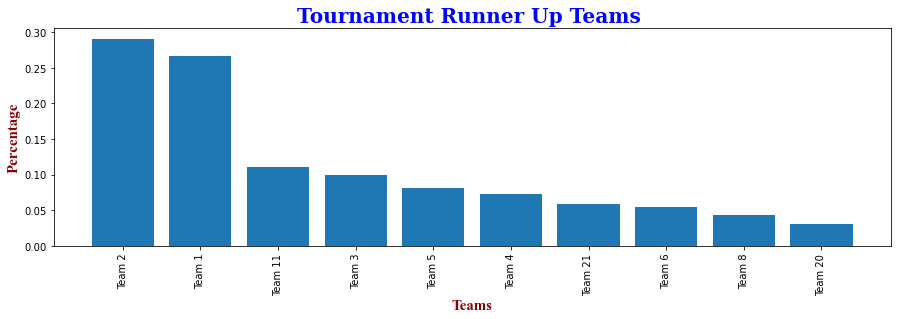

```python
plt.figure(figsize=(15,4))
plt.bar(rnp['Team'].head(10),rnp['Runner_up_per'].head(10))
plt.xticks(rotation=90)
plt.xlabel('Teams',fontdict=font1)
plt.ylabel('Percentage',fontdict=font1)
plt.title('Tournament Runner Up Teams ',fontdict=font2);
```

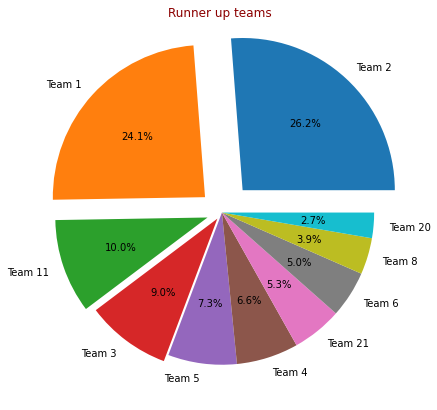

```python
plt.figure(figsize=(15,7))
plt.pie(rnp['Runner_up_per'].head(10),labels=rnp['Team'].head(10),autopct='%1.1f%%',explode = (0.20,0.15,0.10,0.05,0,0,0,0,0,0));
plt.title('Runner up teams ',c='darkred');
```

```python
print('The most Runner up team : \n',rnp.Team.head())
```

```
The most Runner up team :
 1      Team 2
0      Team 1
10    Team 11
2      Team 3
4      Team 5
Name: Team, dtype: object
```

```python
df['High_goals']=round(df['BasketScored']/(df['BasketScored']+df['BasketGiven']),3)
df.head()
```

|  | Team | Tournament | Score | PlayedGames | WonGames | DrawnGames | LostGames | BasketScored | BasketGiven | TournamentChampion | Runner-up | TeamLaunch | HighestPositionHeld | High_perf_team | Low_perf_team | tourn_win_per | Runner_up_per | High_goals |
| --- | --- | --- | --- | --- | --- | --- | --- | --- | --- | --- | --- | --- | --- | --- | --- | --- | --- | --- |
| 0 | Team 1 | 86 | 4385 | 2762 | 1647 | 552 | 563 | 5947 | 3140 | 33 | 23 | 1929 | 1 | 0.596 | 0.204 | 0.384 | 0.267 | 0.654 |
| 1 | Team 2 | 86 | 4262 | 2762 | 1581 | 573 | 608 | 5900 | 3114 | 25 | 25 | 1929 | 1 | 0.572 | 0.220 | 0.291 | 0.291 | 0.655 |
| 2 | Team 3 | 80 | 3442 | 2614 | 1241 | 598 | 775 | 4534 | 3309 | 10 | 8 | 1929 | 1 | 0.475 | 0.296 | 0.125 | 0.100 | 0.578 |
| 3 | Team 4 | 82 | 3386 | 2664 | 1187 | 616 | 861 | 4398 | 3469 | 6 | 6 | 1931-32 | 1 | 0.446 | 0.323 | 0.073 | 0.073 | 0.559 |
| 4 | Team 5 | 86 | 3368 | 2762 | 1209 | 633 | 920 | 4631 | 3700 | 8 | 7 | 1929 | 1 | 0.438 | 0.333 | 0.093 | 0.081 | 0.556 |

```python
hgp=df[['Team','High_goals']].sort_values('High_goals',ascending=False)
hgp.head()
```

|  | Team | High_goals |
| --- | --- | --- |
| 1 | Team 2 | 0.655 |
| 0 | Team 1 | 0.654 |
| 2 | Team 3 | 0.578 |
| 3 | Team 4 | 0.559 |
| 4 | Team 5 | 0.556 |

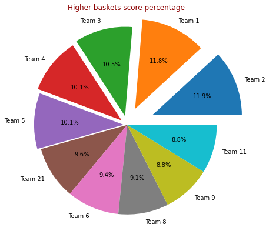

```python
plt.figure(figsize=(15,7))
plt.pie(hgp['High_goals'].head(10),labels=hgp['Team'].head(10),autopct='%1.1f%%',explode = (0.30,0.20,0.10,0.08,0.04,0,0,0,0,0));
plt.title('Higher baskets score percentage ',c='darkred');
```

```python
hph=df[df['HighestPositionHeld']==1].loc[:,['Team','HighestPositionHeld']]
print(hph.HighestPositionHeld.sum())
hph
```

```
9
```

|  | Team | HighestPositionHeld |
| --- | --- | --- |
| 0 | Team 1 | 1 |
| 1 | Team 2 | 1 |
| 2 | Team 3 | 1 |
| 3 | Team 4 | 1 |
| 4 | Team 5 | 1 |
| 5 | Team 6 | 1 |
| 7 | Team 8 | 1 |
| 9 | Team 10 | 1 |
| 10 | Team 11 | 1 |

### Teams are played as winners and also runner ups

```python
A1=pd.merge(twp,rnp,how='inner',on='Team')
A1.head(10)
```

|  | Team | tourn_win_per | Runner_up_per |
| --- | --- | --- | --- |
| 0 | Team 1 | 0.384 | 0.267 |
| 1 | Team 2 | 0.291 | 0.291 |
| 2 | Team 3 | 0.125 | 0.100 |
| 3 | Team 5 | 0.093 | 0.081 |
| 4 | Team 4 | 0.073 | 0.073 |
| 5 | Team 8 | 0.029 | 0.043 |
| 6 | Team 11 | 0.022 | 0.111 |
| 7 | Team 10 | 0.020 | 0.000 |
| 8 | Team 6 | 0.014 | 0.055 |
| 9 | Team 37 | 0.000 | 0.000 |

The above mentioned Teams are participated in Tournaments has maximum percentage of either winning a tournment or runner_up

```python
A2=df[['Team','TeamLaunch']]
A2.head()
```

|  | Team | TeamLaunch |
| --- | --- | --- |
| 0 | Team 1 | 1929 |
| 1 | Team 2 | 1929 |
| 2 | Team 3 | 1929 |
| 3 | Team 4 | 1931-32 |
| 4 | Team 5 | 1929 |

```python
A3=pd.merge(A2,A1,how='outer',on='Team')
A3.head(10)
```

|  | Team | TeamLaunch | tourn_win_per | Runner_up_per |
| --- | --- | --- | --- | --- |
| 0 | Team 1 | 1929 | 0.384 | 0.267 |
| 1 | Team 2 | 1929 | 0.291 | 0.291 |
| 2 | Team 3 | 1929 | 0.125 | 0.100 |
| 3 | Team 4 | 1931-32 | 0.073 | 0.073 |
| 4 | Team 5 | 1929 | 0.093 | 0.081 |
| 5 | Team 6 | 1934-35 | 0.014 | 0.055 |
| 6 | Team 7 | 1929 | 0.000 | 0.000 |
| 7 | Team 8 | 1929 | 0.029 | 0.043 |
| 8 | Team 9 | 1939-40 | 0.000 | 0.017 |
| 9 | Team 10 | 1932-33 | 0.020 | 0.000 |

```python
A4=pd.merge(A3,hpt,how='inner',on='Team')
A4.head(10)
```

|  | Team | TeamLaunch | tourn_win_per | Runner_up_per | High_perf_team |
| --- | --- | --- | --- | --- | --- |
| 0 | Team 1 | 1929 | 0.384 | 0.267 | 0.596 |
| 1 | Team 2 | 1929 | 0.291 | 0.291 | 0.572 |
| 2 | Team 3 | 1929 | 0.125 | 0.100 | 0.475 |
| 3 | Team 4 | 1931-32 | 0.073 | 0.073 | 0.446 |
| 4 | Team 5 | 1929 | 0.093 | 0.081 | 0.438 |
| 5 | Team 6 | 1934-35 | 0.014 | 0.055 | 0.411 |
| 6 | Team 7 | 1929 | 0.000 | 0.000 | 0.361 |
| 7 | Team 8 | 1929 | 0.029 | 0.043 | 0.375 |
| 8 | Team 9 | 1939-40 | 0.000 | 0.017 | 0.351 |
| 9 | Team 10 | 1932-33 | 0.020 | 0.000 | 0.351 |

```python
A5=pd.merge(A4,lpt,how='inner',on='Team')
A5.head(10)
```

|  | Team | TeamLaunch | tourn_win_per | Runner_up_per | High_perf_team | Low_perf_team |
| --- | --- | --- | --- | --- | --- | --- |
| 0 | Team 1 | 1929 | 0.384 | 0.267 | 0.596 | 0.204 |
| 1 | Team 2 | 1929 | 0.291 | 0.291 | 0.572 | 0.220 |
| 2 | Team 3 | 1929 | 0.125 | 0.100 | 0.475 | 0.296 |
| 3 | Team 4 | 1931-32 | 0.073 | 0.073 | 0.446 | 0.323 |
| 4 | Team 5 | 1929 | 0.093 | 0.081 | 0.438 | 0.333 |
| 5 | Team 6 | 1934-35 | 0.014 | 0.055 | 0.411 | 0.368 |
| 6 | Team 7 | 1929 | 0.000 | 0.000 | 0.361 | 0.407 |
| 7 | Team 8 | 1929 | 0.029 | 0.043 | 0.375 | 0.374 |
| 8 | Team 9 | 1939-40 | 0.000 | 0.017 | 0.351 | 0.386 |
| 9 | Team 10 | 1932-33 | 0.020 | 0.000 | 0.351 | 0.395 |

```python
A6=pd.merge(A4,hgp,how='inner',on='Team')
A6.head()
```

|  | Team | TeamLaunch | tourn_win_per | Runner_up_per | High_perf_team | High_goals |
| --- | --- | --- | --- | --- | --- | --- |
| 0 | Team 1 | 1929 | 0.384 | 0.267 | 0.596 | 0.654 |
| 1 | Team 2 | 1929 | 0.291 | 0.291 | 0.572 | 0.655 |
| 2 | Team 3 | 1929 | 0.125 | 0.100 | 0.475 | 0.578 |
| 3 | Team 4 | 1931-32 | 0.073 | 0.073 | 0.446 | 0.559 |
| 4 | Team 5 | 1929 | 0.093 | 0.081 | 0.438 | 0.556 |

```python
df_final=pd.merge(A6,hph,how='inner',on='Team')
df_final.head(10)
```

|  | Team | TeamLaunch | tourn_win_per | Runner_up_per | High_perf_team | High_goals | HighestPositionHeld |
| --- | --- | --- | --- | --- | --- | --- | --- |
| 0 | Team 1 | 1929 | 0.384 | 0.267 | 0.596 | 0.654 | 1 |
| 1 | Team 2 | 1929 | 0.291 | 0.291 | 0.572 | 0.655 | 1 |
| 2 | Team 3 | 1929 | 0.125 | 0.100 | 0.475 | 0.578 | 1 |
| 3 | Team 4 | 1931-32 | 0.073 | 0.073 | 0.446 | 0.559 | 1 |
| 4 | Team 5 | 1929 | 0.093 | 0.081 | 0.438 | 0.556 | 1 |
| 5 | Team 6 | 1934-35 | 0.014 | 0.055 | 0.411 | 0.522 | 1 |
| 6 | Team 8 | 1929 | 0.029 | 0.043 | 0.375 | 0.500 | 1 |
| 7 | Team 10 | 1932-33 | 0.020 | 0.000 | 0.351 | 0.464 | 1 |
| 8 | Team 11 | 1941-42 | 0.022 | 0.111 | 0.368 | 0.484 | 1 |

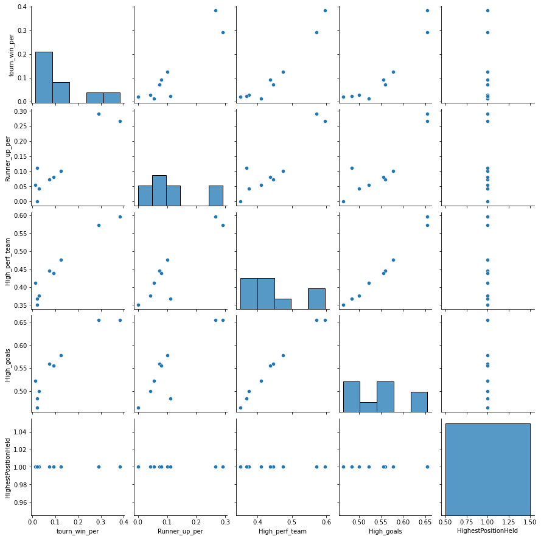

```python
plt.figure(figsize=(5,5))
sns.pairplot(df_final);
```

```python
df_final.corr()
```

|  | tourn_win_per | Runner_up_per | High_perf_team | High_goals | HighestPositionHeld |
| --- | --- | --- | --- | --- | --- |
| tourn_win_per | 1.000000 | 0.925551 | 0.961608 | 0.927440 | NaN |
| Runner_up_per | 0.925551 | 1.000000 | 0.913245 | 0.891789 | NaN |
| High_perf_team | 0.961608 | 0.913245 | 1.000000 | 0.991156 | NaN |
| High_goals | 0.927440 | 0.891789 | 0.991156 | 1.000000 | NaN |
| HighestPositionHeld | NaN | NaN | NaN | NaN | NaN |

Every column has a strong positive correlation ship with other column.

- by this way may understood the teams in df_final are highly selctive teams.
- the correlation is shown in following heat map

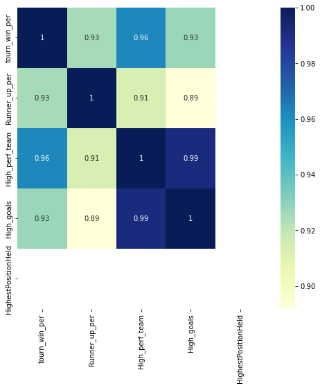

```python
plt.figure(figsize=(8,8))
sns.heatmap(df_final.corr(),annot=True,cmap='YlGnBu');
```

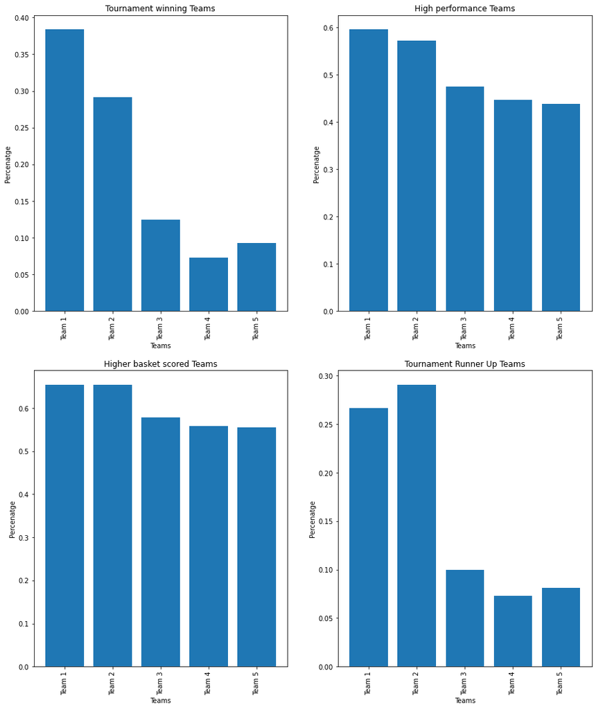

```python
plt.figure(figsize=(15,18))
plt.subplot(2,2,1)
plt.bar(df_final['Team'].head(),df_final['tourn_win_per'].head())
plt.xlabel('Teams')
plt.ylabel('Percenatge')
plt.title('Tournament winning Teams')
plt.xticks(rotation=90)

plt.subplot(2,2,2)
plt.bar(df_final['Team'].head(),df_final['High_perf_team'].head())
plt.xlabel('Teams')
plt.ylabel('Percenatge')
plt.title('High performance Teams')
plt.xticks(rotation=90)

plt.subplot(2,2,3)
plt.bar(df_final['Team'].head(),df_final['High_goals'].head())
plt.xlabel('Teams')
plt.ylabel('Percenatge')
plt.title('Higher basket scored Teams')
plt.xticks(rotation=90)

plt.subplot(2,2,4)
plt.bar(df_final['Team'].head(),df_final['Runner_up_per'].head())
plt.xlabel('Teams')
plt.ylabel('Percenatge')
plt.title('Tournament Runner Up Teams')
plt.xticks(rotation=90);
```

```python
print("Company X can approach the following Teams to win their Deal : \n")
df_final.Team.head()
```

```
Company X can approach the following Teams to win their Deal :
```

```
0    Team 1
1    Team 2
2    Team 3
3    Team 4
4    Team 5
Name: Team, dtype: object
```

## Part 2 Q3 Please include any improvements or suggestions to the association management on quality, quantity, variety, velocity, veracity etc. on the data points collected by the association to perform a better data analysis in future. At-least 1 suggestion for each point.

- ## Quality :

There are lot of missing values observed.instead of mentioning hyphene symbols if values mention is suggestable

- ## Quantity :

most of the data is skewed and needs more data for proper conclusion

- ## Variety:

There are the columns with string type (object) data,need to convert to numericals.datatype format changing is suggestable

- ## velocity As mentioned earlier due to lot of missing values and convertion of datatypes requires more time to process the data that changes are suggestable
- ## Variety As mentioned different datatypes and hyphene values are need to be clear

# • DOMAIN: Startup ecosystem

• CONTEXT: Company X is a EU online publisher focusing on the startups industry. The company specifically reports on the business related to technology news, analysis of emerging trends and profiling of new tech businesses and products. Their event i.e. Startup Battlefield is the world’s pre-eminent startup competition. Startup Battlefield features 15-30 top early stage startups pitching top judges in front of a vast live audience, present in person and online. • DATA DESCRIPTION: CompanyX_EU.csv - Each row in the dataset is a Start-up company and the columns describe the company. • DATA DICTIONARY:

1. Startup: Name of the company
2. Product: Actual product
3. Funding: Funds raised by the company in USD
4. Event: The event the company participated in
5. Result: Described by Contestant, Finalist, Audience choice, Winner or Runner up
6. OperatingState: Current status of the company, Operating ,Closed, Acquired or IPO *Dataset has been downloaded from the internet. All the credit for the dataset goes to the original creator of the data. • PROJECT OBJECTIVE: Analyse the data of the various companies from the given dataset and perform the tasks that are specified in the below steps. Draw insights from the various attributes that are present in the dataset, plot distributions, state hypotheses and draw conclusions from the dataset

# Part 3 Q1) Read the CSV file

```python
data=pd.read_csv('CompanyX_EU.csv')
```

# Part 3 Q2 Data exploration.

## A.Check the datatypes of each attribute

```python
data.head()
```

|  | Startup | Product | Funding | Event | Result | OperatingState |
| --- | --- | --- | --- | --- | --- | --- |
| 0 | 2600Hz | 2600hz.com | NaN | Disrupt SF 2013 | Contestant | Operating |
| 1 | 3DLT | 3dlt.com | $630K | Disrupt NYC 2013 | Contestant | Closed |
| 2 | 3DPrinterOS | 3dprinteros.com | NaN | Disrupt SF 2016 | Contestant | Operating |
| 3 | 3Dprintler | 3dprintler.com | $1M | Disrupt NY 2016 | Audience choice | Operating |
| 4 | 42 Technologies | 42technologies.com | NaN | Disrupt NYC 2013 | Contestant | Operating |

```python
data.info()
```

```
<class 'pandas.core.frame.DataFrame'>
RangeIndex: 662 entries, 0 to 661
Data columns (total 6 columns):
 #   Column          Non-Null Count  Dtype
---  ------          --------------  -----
 0   Startup         662 non-null    object
 1   Product         656 non-null    object
 2   Funding         448 non-null    object
 3   Event           662 non-null    object
 4   Result          662 non-null    object
 5   OperatingState  662 non-null    object
dtypes: object(6)
memory usage: 31.2+ KB
```

```python
data.dtypes
```

```
Startup           object
Product           object
Funding           object
Event             object
Result            object
OperatingState    object
dtype: object
```

```python
data.shape
```

```
(662, 6)
```

## B.Check for null values in the attributes.

```python
data.isnull().sum()
```

```
Startup             0
Product             6
Funding           214
Event               0
Result              0
OperatingState      0
dtype: int64
```

There are null values are observed in Product and Funding attributes

# 3. Data preprocessing & visualisation

## A) Drop the null values

```python
data.dropna(inplace=True)
```

```python
data.isnull().sum()
```

```
Startup           0
Product           0
Funding           0
Event             0
Result            0
OperatingState    0
dtype: int64
```

```python
data.shape
```

```
(446, 6)
```

```python
data.head()
```

|  | Startup | Product | Funding | Event | Result | OperatingState |
| --- | --- | --- | --- | --- | --- | --- |
| 1 | 3DLT | 3dlt.com | $630K | Disrupt NYC 2013 | Contestant | Closed |
| 3 | 3Dprintler | 3dprintler.com | $1M | Disrupt NY 2016 | Audience choice | Operating |
| 5 | 5to1 | 5to1.com | $19.3M | TC50 2009 | Contestant | Acquired |
| 6 | 8 Securities | 8securities.com | $29M | Disrupt Beijing 2011 | Finalist | Operating |
| 10 | AdhereTech | adheretech.com | $1.8M | Hardware Battlefield 2014 | Contestant | Operating |

## B. Convert the ‘Funding’ features to a numerical value.

```python
data.loc[:,'Funds_in_million'] = data['Funding'].apply(lambda x: float(x[1:-1])/1000 if x[-1] == 'K' else (float(x[1:-1])*1000 if x[-1] == 'B' else float(x[1:-1])))
```

```python
data.head()
```

|  | Startup | Product | Funding | Event | Result | OperatingState | Funds_in_million |
| --- | --- | --- | --- | --- | --- | --- | --- |
| 1 | 3DLT | 3dlt.com | $630K | Disrupt NYC 2013 | Contestant | Closed | 0.63 |
| 3 | 3Dprintler | 3dprintler.com | $1M | Disrupt NY 2016 | Audience choice | Operating | 1.00 |
| 5 | 5to1 | 5to1.com | $19.3M | TC50 2009 | Contestant | Acquired | 19.30 |
| 6 | 8 Securities | 8securities.com | $29M | Disrupt Beijing 2011 | Finalist | Operating | 29.00 |
| 10 | AdhereTech | adheretech.com | $1.8M | Hardware Battlefield 2014 | Contestant | Operating | 1.80 |

## C) Plot box plot for funds in million

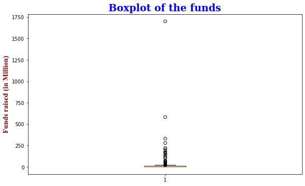

```python
plt.figure(figsize=(10,6))
plot = plt.boxplot(data.Funds_in_million)
plt.title('Boxplot of the funds',color='b',fontdict=font2)
plt.ylabel("Funds raised (in Million)",fontdict=font1);
```

## D) Check the number of outliers greater than the upper fence

```python
upper_fence=plot['caps'][1].get_data()[1][1]
print(upper_fence)
```

```
22.0
```

## D Check the number of outliers greater than the upper fence

```python
number_of_outliers = len(data[data['Funds_in_million'] > upper_fence])
print(number_of_outliers)
```

```
60
```

```python
data[data['Funds_in_million'] > upper_fence]
```

|  | Startup | Product | Funding | Event | Result | OperatingState | Funds_in_million |
| --- | --- | --- | --- | --- | --- | --- | --- |
| 6 | 8 Securities | 8securities.com | $29M | Disrupt Beijing 2011 | Finalist | Operating | 29.0 |
| 31 | Anyclip | anyclip.com | $24M | TC50 2009 | Finalist | Operating | 24.0 |
| 40 | Artsy | artsy.net | $50.9M | Disrupt NYC 2010 | Contestant | Operating | 50.9 |
| 49 | Badgeville | badgeville.com | $40M | Disrupt SF 2010 | Finalist | Acquired | 40.0 |
| 56 | Betterment | betterment.com | $205M | Disrupt NYC 2010 | Finalist | Operating | 205.0 |
| 108 | Clickable | clickable.com | $32.5M | TC40 2007 | Finalist | Acquired | 32.5 |
| 113 | Cloudflare | cloudflare.com | $182.1M | Disrupt SF 2010 | Runner up | Operating | 182.1 |
| 128 | Credit Sesame | creditsesame.com | $35.4M | Disrupt SF 2010 | Contestant | Operating | 35.4 |
| 130 | CrowdFlower Inc. | crowdflower.com | $38M | TC50 2009 | Contestant | Operating | 38.0 |
| 132 | Cubic Telecom | cubictelecom.com | $37.1M | TC40 2007 | Contestant | Operating | 37.1 |
| 138 | DataSift | datasift.com | $72M | Disrupt SF 2010 | Finalist | Operating | 72.0 |
| 139 | DataXu | dataxu.com | $64M | TC50 2009 | Contestant | Operating | 64.0 |
| 154 | Dropbox | dropbox.com | $1.7B | TC50 2008 | Contestant | Operating | 1700.0 |
| 166 | Enigma | enigma.io | $34.6M | Disrupt NYC 2013 | Winner | Operating | 34.6 |
| 172 | EverythingMe | everything.me | $35.5M | Disrupt NYC 2011 | Contestant | Closed | 35.5 |
| 179 | Famo.us | famo.us | $30.1M | Disrupt SF 2012 | Contestant | Operating | 30.1 |
| 180 | Farmigo | farmigo.com | $26M | Disrupt SF 2011 | Finalist | Operating | 26.0 |
| 188 | Fitbit | fitbit.com | $66M | TC50 2008 | Finalist | Ipo | 66.0 |
| 191 | Flock | flock.com | $28.3M | TC40 2007 | Contestant | Acquired | 28.3 |
| 209 | Getaround | getaround.com | $103M | Disrupt NYC 2011 | Winner | Operating | 103.0 |
| 213 | Gild | gild.com | $25.9M | Disrupt SF 2010 | Contestant | Acquired | 25.9 |
| 215 | Glide | glide.me | $36.5M | Disrupt NYC 2013 | Audience choice | Operating | 36.5 |
| 225 | Grockit | grockit.com | $44.7M | TC50 2008 | Finalist | Acquired | 44.7 |
| 231 | HackerRank | hackerrank.com | $24.2M | Disrupt SF 2012 | Contestant | Operating | 24.2 |
| 271 | Ionic Security | ionicsecurity.com | $122.4M | Disrupt SF 2012 | Contestant | Operating | 122.4 |
| 276 | IZEA | izea.com | $34.9M | Disrupt NYC 2010 | Contestant | Ipo | 34.9 |
| 279 | Jiff | jiff.com | $67.8M | Disrupt SF 2011 | Contestant | Acquired | 67.8 |
| 282 | Kaltura | kaltura.com | $166.1M | TC40 2007 | Audience choice | Operating | 166.1 |
| 302 | Layer | layer.com | $42.1M | Disrupt SF 2013 | Winner | Operating | 42.1 |
| 305 | LearnVest | learnvest.com | $69M | TC50 2009 | Contestant | Acquired | 69.0 |
| 313 | LiveIntent | liveintent.com | $65.1M | Disrupt NYC 2010 | Audience choice | Operating | 65.1 |
| 325 | Lystable | lystable.com | $25.1M | Disrupt London 2015 | Finalist | Operating | 25.1 |
| 346 | Mint | mint.com | $31.8M | TC40 2007 | Winner | Acquired | 31.8 |
| 389 | OrderWithMe | orderwithme.com | $37M | Disrupt Beijing 2011 | Winner | Operating | 37.0 |
| 393 | Osmo | playosmo.com | $38.5M | Disrupt SF 2013 | Contestant | Operating | 38.5 |
| 394 | Ossia | ossia.com | $25.5M | Disrupt SF 2013 | Runner up | Operating | 25.5 |
| 398 | Owlet Baby Care | owletcare.com | $24M | Hardware Battlefield 2014 | Runner up | Operating | 24.0 |
| 427 | Postmates | postmates.com | $278M | Disrupt SF 2011 | Contestant | Operating | 278.0 |
| 432 | Prism Skylabs | prism.com | $24M | Disrupt SF 2011 | Runner up | Operating | 24.0 |
| 435 | PubMatic | pubmatic.com | $63M | TC40 2007 | Contestant | Operating | 63.0 |
| 460 | Roadie | roadie.com | $25M | Disrupt NYC 2014 | Audience choice | Operating | 25.0 |
| 471 | SeatGeek | seatgeek.com | $160M | TC50 2009 | Contestant | Operating | 160.0 |
| 546 | StyleSeat | styleseat.com | $40M | Disrupt NYC 2011 | Contestant | Operating | 40.0 |
| 555 | Symphony Commerce | symphonycommerce.com | $47.4M | Disrupt NYC 2011 | Contestant | Operating | 47.4 |
| 560 | Talkdesk | talkdesk.com | $24.5M | Disrupt NYC 2012 | Contestant | Operating | 24.5 |
| 581 | TouchPal | touchpal.com | $25M | Disrupt Beijing 2011 | Finalist | Operating | 25.0 |
| 593 | TrueCar | truecar.com | $332.4M | TC50 2008 | Contestant | Ipo | 332.4 |
| 598 | UberConference | uberconference.com | $35M | Disrupt NYC 2012 | Winner | Operating | 35.0 |
| 606 | Upwork | upwork.com | $168.8M | TC50 2009 | Audience choice | Operating | 168.8 |
| 615 | VideoSurf | videosurf.com | $28M | TC50 2008 | Contestant | Acquired | 28.0 |
| 625 | Voxy | voxy.com | $30.8M | Disrupt SF 2010 | Contestant | Operating | 30.8 |
| 643 | Xobni | yahoo.com | $41.8M | TC40 2007 | Contestant | Acquired | 41.8 |
| 644 | Yammer | yammer.com | $142M | TC50 2008 | Winner | Acquired | 142.0 |
| 647 | Yext | yext.com | $117.8M | TC50 2009 | Contestant | Ipo | 117.8 |
| 649 | YouNow | younow.com | $26M | Disrupt SF 2011 | Contestant | Operating | 26.0 |
| 650 | YourMechanic | yourmechanic.com | $28M | Disrupt SF 2012 | Winner | Operating | 28.0 |
| 654 | ZEFR | zefr.com | $62.1M | Disrupt NYC 2010 | Contestant | Operating | 62.1 |
| 656 | Zenefits | zenefits.com | $583.6M | Disrupt NYC 2013 | Finalist | Operating | 583.6 |
| 659 | Zocdoc | zocdoc.com | $223M | TC40 2007 | Contestant | Operating | 223.0 |
| 661 | Zumper | zumper.com | $31.5M | Disrupt SF 2012 | Finalist | Operating | 31.5 |

```python
data.drop(data[data.Funds_in_million > upper_fence].index, inplace = True)
```

```python
print(data.shape)
```

```
(386, 7)
```

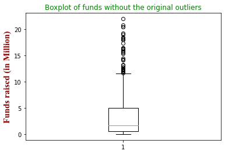

```python
plot = plt.boxplot(data.Funds_in_million)
plt.title('Boxplot of funds without the original outliers',c='g')
plt.ylabel("Funds raised (in Million)",fontdict=font1)
plt.show()
```

## E) Check frequency of the Operating State features classes

```python
print(data.OperatingState.value_counts())
```

```
Operating    275
Closed        56
Acquired      55
Name: OperatingState, dtype: int64
```

In our Company X there 275 Companies are Operating and 56 companies are Closed

## Q4 A Is there any significant difference between Funds raised by companies that are still operating vs companies that closed down?

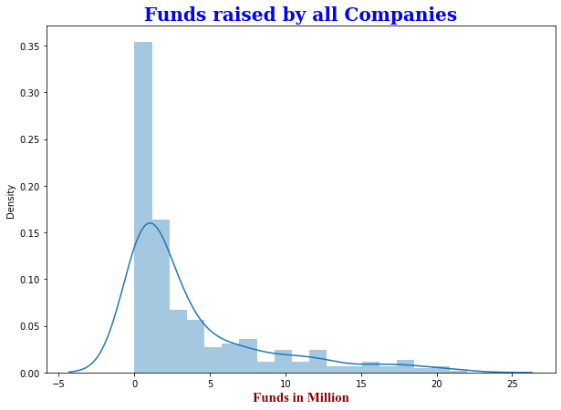

```python
from warnings import filterwarnings
filterwarnings("ignore")

plt.figure(figsize=(10,7))
sns.distplot(data.Funds_in_million)
plt.xlabel('Funds in Million',fontdict=font1)
plt.title('Funds raised by all Companies',fontdict=font2);
```

```python
print(data['Funds_in_million'].describe())
```

```
count    386.00000
mean       3.72514
std        4.73236
min        0.00500
25%        0.60000
50%        1.70000
75%        5.00000
max       22.00000
Name: Funds_in_million, dtype: float64
```

by above statistical data we observed that the data mean is greater than median Even after removing ouliers the data is Right skewed

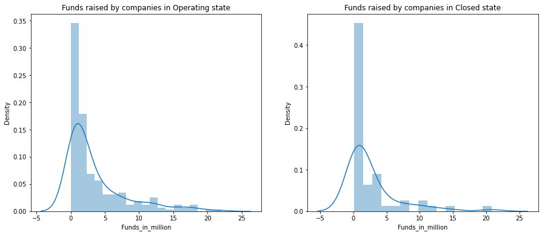

```python
fig, ax = plt.subplots(1, 2)

fig.set_figheight(6)
fig.set_figwidth(15)

sns.distplot(data.loc[data.OperatingState == 'Operating', 'Funds_in_million'], ax = ax[0])
sns.distplot(data.loc[data.OperatingState =='Closed', 'Funds_in_million'], ax = ax[1])

ax[0].set_title('Funds raised by companies in Operating state')
ax[1].set_title('Funds raised by companies in Closed state');
```

- The distributions are almost same by the visual representaions
- By this visual representaions we can not claim is there significant difference between funds raised by the companies in operating state and closed
- to prove the significant difference between them we perform a Hypothesis test
- Since we want to compare the difference in means of the samples , we perform 2 sample z-test (since sample size>30)

## Q4 B Write the null hypothesis and alternative hypothesis

**Null hypothesis (Ho)** : There is no difference between the two means

**Alternate hypothesis (Ha)** : There is significant difference between the two means

## Q4 C Test for significance and conclusion

```python
import statsmodels.stats
from statsmodels.stats.weightstats import ztest
```

```python
sample1=data[data.OperatingState == 'Operating']['Funds_in_million']
sample2=data[data.OperatingState == 'Closed']['Funds_in_million']

alpha=0.05

z_stat,p_value=ztest(sample1,sample2)

print('z_statistic value : %1.3f' %z_stat)
print('p_value : %1.3f' %p_value)
```

```
z_statistic value : 1.304
p_value : 0.192
```

```python
if (p_value > alpha):

    print('since p_value {} greater than significance level {} the difference is not siginificant and fail to reject Null Hypothesis' .format(round(p_value,3),alpha))
else :

     print('since p_value {} less than significance level {} the difference is siginificant and reject Null Hypothesis' .format(round(p_value,3),alpha))
```

```
since p_value 0.192 greater than significance level 0.05 the difference is not siginificant and fail to reject Null Hypothesis
```

## Conclusion

By the Hypothesis test, there is no significant difference between funds raised by the companies in operating state and closed

## Q4 D Make a copy of the original data frame

```python
data_1=data.copy(deep=True)
data_1.head()
```

|  | Startup | Product | Funding | Event | Result | OperatingState | Funds_in_million |
| --- | --- | --- | --- | --- | --- | --- | --- |
| 1 | 3DLT | 3dlt.com | $630K | Disrupt NYC 2013 | Contestant | Closed | 0.63 |
| 3 | 3Dprintler | 3dprintler.com | $1M | Disrupt NY 2016 | Audience choice | Operating | 1.00 |
| 5 | 5to1 | 5to1.com | $19.3M | TC50 2009 | Contestant | Acquired | 19.30 |
| 10 | AdhereTech | adheretech.com | $1.8M | Hardware Battlefield 2014 | Contestant | Operating | 1.80 |
| 11 | AdRocket | adrocket.com | $1M | TC50 2008 | Contestant | Closed | 1.00 |

## Q4 E Check frequency distribution of Result variables.

```python
print(data_1.Result.value_counts())
```

```
Contestant         282
Finalist            52
Audience choice     20
Winner              17
Runner up           15
Name: Result, dtype: int64
```

## Part 3 Q4 F Calculate percentage of winners that are still operating and percentage of contestants that are still operating

```python
winners=data_1.Result.value_counts()[1:].sum()
contestants=data_1.Result.value_counts()['Contestant']
print('winners :',winners)
print('contestants :',contestants)
```

```
winners : 104
contestants : 282
```

```python
contestants_operating=data_1[data_1['Result']=='Contestant']['OperatingState'].value_counts()[0]
winners_operating=data_1[data_1['Result']!='Contestant']['OperatingState'].value_counts()[0]
print('the contestants operating : ',contestants_operating)
print('the winners operating:',winners_operating)
```

```
the contestants operating :  194
the winners operating: 81
```

```python
print('The proportion of companies that are operating contestants:',round(contestants_operating/contestants,3) )
print('The proportion of companies that are operating winners:',round(winners_operating/contestants,3) )
```

[output not shown]

## Q4 G Write your hypothesis comparing the proportion of companies that are operating between winners and contestants:

- there is a some difference between the proportion of the companies that are operating between winners and contestants
- to prove the significance difference between the proportion of companies that are operating between winners and contestants we perform the hypothesis test
- we perform the Z-test for proportions

**Null hypothesis (Ho)**:

The proportion of companies that are operating is the same in both categories - winners and contestants

**Alternative hypothesis (Ha)**:

The proportion of companies that are operating is significantly different from each other, among the two categories

## Q4 H Test for significance and conclusion

```python
from statsmodels.stats.proportion import proportions_ztest

test_statistic, p_value = proportions_ztest([contestants_operating, winners_operating], [contestants, winners])

alpha=0.05 # level of significance

print('pvalue : %0.3f' %p_value)
```

```
pvalue : 0.080
```

```python
if p_value<alpha:
    print('The proportion of companies that are operating is significantly different from each other, among the two categories and Reject Null Hypothesis')
else:
     print('The proportion of companies that are operating is the same in both categories - winners and contestants and Fail to Reject Null Hypothesis')
```

```
The proportion of companies that are operating is the same in both categories - winners and contestants and Fail to Reject Null Hypothesis
```

### Conclusion

- There is no significant difference between the companies that are operating as winners and contestants

## Q4 I Select only the Event that has ‘disrupt’ keyword from 2013 onwards

```python
events=data_1[data_1.Event.apply(lambda x : 'Disrupt' in x and int(x[-4:])>2012)].Event
print(events)
```

```
1         Disrupt NYC 2013
3          Disrupt NY 2016
13         Disrupt SF 2015
14     Disrupt London 2016
16         Disrupt SF 2015
              ...
635        Disrupt NY 2015
641       Disrupt NYC 2013
642        Disrupt SF 2014
646    Disrupt London 2015
660        Disrupt SF 2013
Name: Event, Length: 185, dtype: object
```

```python
print(events.value_counts())
```

```
Disrupt NY 2015        21
Disrupt NYC 2013       19
Disrupt SF 2015        19
Disrupt SF 2014        19
Disrupt SF 2013        19
Disrupt SF 2016        17
Disrupt NY 2016        16
Disrupt NYC 2014       15
Disrupt London 2015    11
Disrupt London 2016    10
Disrupt EU 2014        10
Disrupt EU 2013         9
Name: Event, dtype: int64
```